# PA1_template

# Check reasonableness of new data set with NA’s replaced and rounded

Histogram of the total number of steps taken each day after missing values are imputed

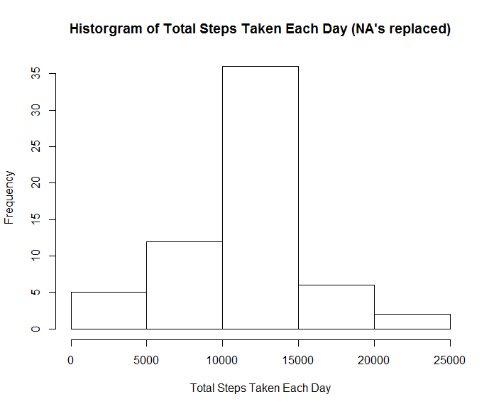

```r
act_data.day.new <- aggregate(act_data.new$steps, list(act_data.new$date), sum)
names(act_data.day.new)[1] <- "day"
names(act_data.day.new)[2] <- "steps"


hist(act_data.day.new$steps,
     main = "Historgram of Total Steps Taken Each Day (NA's replaced)",
     xlab = "Total Steps Taken Each Day")
```

Mean and median of total nubmer of steps taken per day with NA’s replaced

```r
mean(act_data.day.new$steps, na.rm = TRUE)
```

```
## [1] 10765.64
```

```r
median(act_data.day.new$steps, na.rm = TRUE)
```

```
## [1] 10762
```

Comparative histogram between old data set with missing values and new data set without missing values

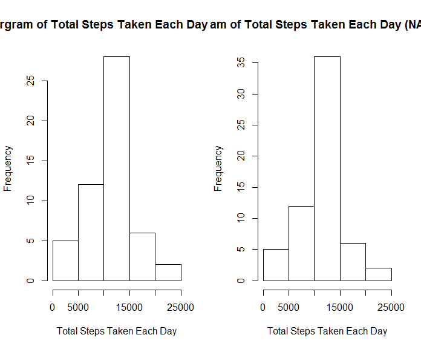

```r
par(mfrow = c(1,2))

hist(act_data.day$steps,
     main = "Historgram of Total Steps Taken Each Day with NA's",
     xlab = "Total Steps Taken Each Day")

hist(act_data.day.new$steps,
     main = "Historgram of Total Steps Taken Each Day (NA's replaced)",
     xlab = "Total Steps Taken Each Day")
```

# Are there differences in activity patterns between weekdays and weekends?

New factor variable with panel plotcomparing the average number of steps taken per 5-minute interval across weekdays and weekends

```r
act_data.new.v2 <- act_data.new
Sys.setlocale("LC_TIME", "English")
```

```
## [1] "English_United States.1252"
```

```r
act_data.new.v2$weekdays <- factor(format(act_data.new.v2$date, '%A'))
levels(act_data.new.v2$weekdays)
```

```
## [1] "Friday"    "Monday"    "Saturday"  "Sunday"    "Thursday"  "Tuesday"
## [7] "Wednesday"
```

```r
levels(act_data.new.v2$weekdays) <- list("weekday" = c("Monday", "Tuesday", "Wednesday", "Thursday", "Friday"), "weekend" = c("Saturday", "Sunday"))

head(act_data.new.v2)
```

```
##     steps       date interval weekdays
## 1       2 2012-10-01        0  weekday
## 63      0 2012-10-01        5  weekday
## 128     0 2012-10-01       10  weekday
## 205     0 2012-10-01       15  weekday
## 264     0 2012-10-01       20  weekday
## 327     2 2012-10-01       25  weekday
```

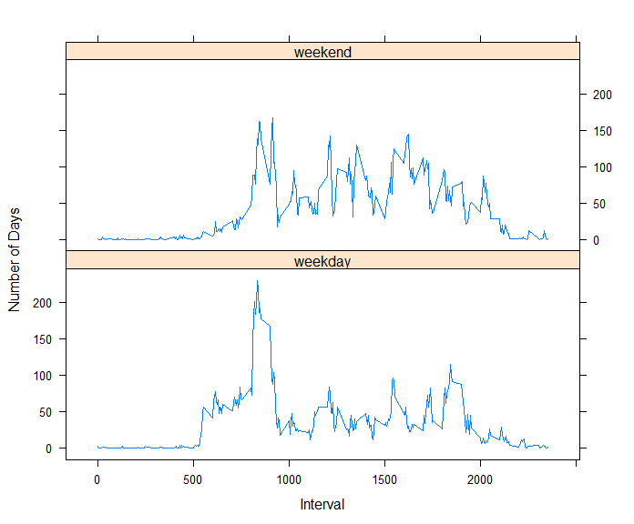

```r
act_data.new.v2.mean.interval <- aggregate(act_data.new.v2$steps, by=list(act_data.new.v2$weekdays, act_data.new.v2$interval), mean, na.rm=TRUE, na.action=NULL)
names(act_data.new.v2.mean.interval)[1] <- "Weekday"
names(act_data.new.v2.mean.interval)[2] <- "Interval"
names(act_data.new.v2.mean.interval)[3] <- "Mean_Steps"

library(lattice)
xyplot(act_data.new.v2.mean.interval$Mean_Steps ~ act_data.new.v2.mean.interval$Interval | act_data.new.v2.mean.interval$Weekday,
          layout=c(1,2),
          type= "l",
          xlab = "Interval",
          ylab = "Number of Days")
```